# Replication of *An instance theory of associative learning* (Jamieson et al. 2012)

Frederik Aust & Deniz Tuzsus

04 Dezember, 2019

```r
knitr::opts_chunk$set(cache = TRUE)
```

Minerva-AL is an instance model of associative learning. In the following we attempted to reproduce a subset (sections 1 and 2) of the simulations reported by Jamieson et al. (2012). We repeated every simulation 100 times, rather than 25 times as in the original report, to reduce random noise in our results.

**For the following effects our simulations yielded results that diverge from the originally reported results.**

```r
source("minerva-al.R")
source("supplementary_functions.R")
```

# Section 1: Acquisition

## Acquisition and extinction

We created cue, outcome, and context vectors and defined the number of trials and replications according to the specifications in the paper.

```r
n_features <- 120
cue_features <- 1:100
a <- context <- outcome <- rep(0, n_features)

a[1:20] <- 1
outcome[101:120] <- 1
context[81:100] <- 1

acquisition_event <- a + context + outcome
extinction_event <- probe <- a + context
```

```r
n_replications <- 100
n_trials <- 200

p_encode <- c(1/3, 2/3, 1)
```

```r
sim_results <- matrix(0, ncol = n_trials, nrow = length(p_encode))

for (r in 1:n_replications) {
  for (i in 1:3) {
    # Memory is empty on first trial
    normalized_echo <- probe_memory(probe, NULL, cue_features)
    expectancy <- expect_event(outcome, normalized_echo)
    memory <- learn(
      normalized_echo
      , acquisition_event
      , p_encode[i]
      , NULL
    )

     # Acquisition trials
    for(j in 2:(n_trials / 2)) {
      normalized_echo <- probe_memory(probe, memory, cue_features)
      expectancy <- c(expectancy, expect_event(outcome, normalized_echo))
      memory <- learn(
        normalized_echo
        , acquisition_event
        , p_encode[i]
        , memory
      )
    }

    # Extinction trials
    for(j in ((n_trials / 2) + 1):n_trials) {
      normalized_echo <- probe_memory(probe, memory, cue_features)
      expectancy <- c(expectancy, expect_event(outcome, normalized_echo))
      memory <- learn(
        normalized_echo
        , extinction_event
        , p_encode[i]
        , memory
      )
    }

    sim_results[i, ] <- sim_results[i, ] + expectancy
  }
}

sim_results <- sim_results / n_replications # Mean of replications
```

The results correspond nicely to those reported in Figure 1.

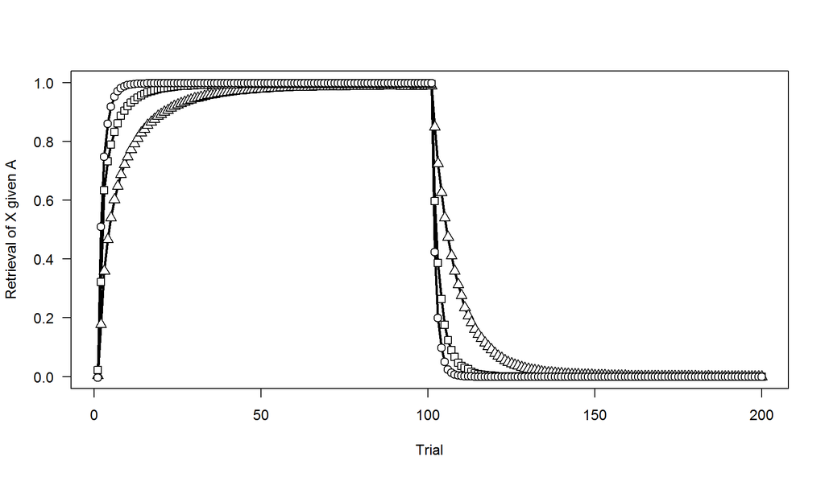

For comparison, the following plot shows the results from the reference Fortran implementation we received from Randall Jamieson (thanks!).

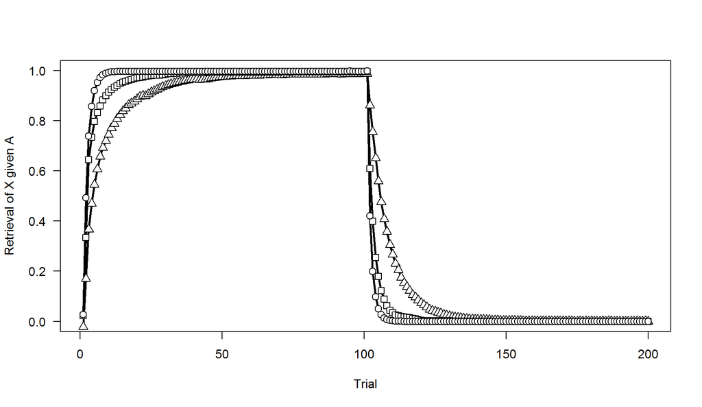

```r
acquisition_files <- list.files(path = "reference_implementation/results", pattern = "Acquisition", full.names = TRUE)

acquisition_extinction <- lapply(
  acquisition_files
  , read.delim
  , skip = 3
  , nrows = 24
  , sep = ""
  , header = FALSE
) %>%
  setNames(
    nm = stringr::str_extract(basename(acquisition_files), "\\d+") %>%
      gsub("0", "0.", .)
  ) %>%
  bind_rows(.id = "L") %>%
  mutate(V2 = as.factor(V2)) %>%
  group_by(L) %>%
  summarise_if(is.numeric, mean)
```

```r
prediction_differences <- sim_results - as.matrix(acquisition_extinction[, -1])

plot(
  1:200
  , rep(NA, 200)
  , ylim = c(-0.2, 0.2)
  , lwd = 2.5
  , xlab = "Trial"
  , ylab = "Absolut difference"
  , las = 1
)

matlines(
  t(prediction_differences)
  , col = "black"
  , lty = c(1, 3, 5)
)

legend("topright", inset = 0.05, legend = unlist(acquisition_extinction[, 1]), lty = c(1, 3, 5))

summary(as.vector(prediction_differences))
```

[output not shown]

## Rapid reacquisition

```r
b <- rep(0, n_features)

b[21:40] <- 1
control_event <- b + context + outcome
control_probe <- b + context
```

```r
n_replications <- 100
n_trials <- 200
```

```r
reacquisition_sim_results <- control_sim_results <- matrix(NA, ncol = n_trials, nrow = length(p_encode) * n_replications)

for (i in 1:length(p_encode)) {
  for (r in 1:n_replications) {
    # Memory is empty on first trial
    normalized_echo <- probe_memory(probe, NULL, cue_features)
    expectancy <- expect_event(outcome, normalized_echo)
    memory <- learn(
      normalized_echo
      , acquisition_event
      , p_encode[i]
      , NULL
    )

    # Acquisition trials
    for(j in 2:50) {
      normalized_echo <- probe_memory(probe, memory, cue_features)
      expectancy <- c(expectancy, expect_event(outcome, normalized_echo))
      memory <- learn(
        normalized_echo
        , acquisition_event
        , p_encode[i]
        , memory
      )
    }

    # Extinction trials
    for(j in 51:100) {
      normalized_echo <- probe_memory(probe, memory, cue_features)
      expectancy <- c(expectancy, expect_event(outcome, normalized_echo))
      memory <- learn(
        normalized_echo
        , extinction_event
        , p_encode[i]
        , memory
      )
    }

    # Reacquisition trials
    reacquisition_memory <- memory
    reacquisition_expectancy <- expectancy

    for(j in 101:200) {
      normalized_echo <- probe_memory(probe, reacquisition_memory, cue_features)
      reacquisition_expectancy <- c(reacquisition_expectancy, expect_event(outcome, normalized_echo))
      reacquisition_memory <- learn(
        normalized_echo
        , acquisition_event
        , p_encode[i]
        , reacquisition_memory
      )
    }

    # Control trials
    control_memory <- memory
    control_expectancy <- expectancy

    for(j in 101:200) {
      normalized_echo <- probe_memory(control_probe, control_memory, cue_features)
      control_expectancy <- c(control_expectancy, expect_event(outcome, normalized_echo))
      control_memory <- learn(
        normalized_echo
        , control_event
        , p_encode[i]
        , control_memory
      )
    }

    reacquisition_sim_results[(i-1)*n_replications + r, ] <- reacquisition_expectancy
    control_sim_results[(i-1)*n_replications + r, ] <- control_expectancy
  }
}
```

For this simulation, we used the same post-extinction memory for the reacquisition and control condition to reduce differences due to random variation during the initial acquisition and extinction trials. The following figure visualizes the changes to the retrieval of X given the cue during the third (re-)acquisition phase. The dashed lines represent the control condition, the solid lines the reacquisition condition.

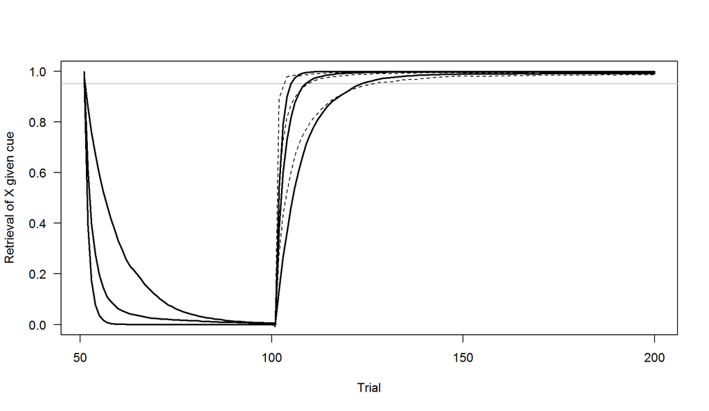

Reproduction of Table 1

| Condtion | 0.33 | 0.67 | 1 |
| --- | --- | --- | --- |
| Reacquisition | 22.27 (0.58) | 8.63 (0.31) | 5.38 (0.09) |
| Control | 25.44 (0.64) | 9.74 (0.32) | 3.02 (0.08) |

Our results diverge quite a bit from those originally reported whenever the learning rate is not perfect.

```r
original <- matrix(
  c("36.2 (5.9)", "62.2 (7.4)", "19.7 (5.1)", "32.1 (6.4)", "5.1 (0.2)", "3.8 (0.1)")
  , ncol = 3
)
knitr::kable(
  cbind(Condition = c("Reacquisition", "Control"), original)
  , col.names = c("Condtion", round(p_encode, 2))
  , caption = "Table 1 as reported by Jamieson et al. (2012)"
)
```

Table 1 as reported by Jamieson et al. (2012)

| Condtion | 0.33 | 0.67 | 1 |
| --- | --- | --- | --- |
| Reacquisition | 36.2 (5.9) | 19.7 (5.1) | 5.1 (0.2) |
| Control | 62.2 (7.4) | 32.1 (6.4) | 3.8 (0.1) |

For comparison, we also implemented the reacquisition protocol in Fortran, based on the reference implementation for the simulation of acqusition and extinction. In this simulation we used different post-extinction memories. The results correspond closely to the results from our previous reproduction efforts.

```r
reacquisition_files <- list.files(path = "reference_implementation/results", pattern = "Reacquisition\\_\\d+", full.names = TRUE)

reacquisition <- lapply(
  reacquisition_files
  , read.delim
  , skip = 3
  , nrows = 24
  , sep = ""
  , header = FALSE
) %>%
  setNames(
    nm = stringr::str_extract(basename(reacquisition_files), "\\d+") %>%
      gsub("0", "0.", .)
  ) %>%
  bind_rows(.id = "L") %>%
  mutate(V2 = as.factor(V2))

mean_reacquisition <- reacquisition %>%
  group_by(L) %>%
  summarise_if(is.numeric, mean)
```

```r
reacquisition_control_files <- list.files(path = "reference_implementation/results", pattern = "Reacquisition\\_\\D+", full.names = TRUE)

reacquisition_control <- lapply(
  reacquisition_control_files
  , read.delim
  , skip = 3
  , nrows = 24
  , sep = ""
  , header = FALSE
) %>%
  setNames(
    nm = stringr::str_extract(basename(reacquisition_control_files), "\\d+") %>%
      gsub("0", "0.", .)
  ) %>%
  bind_rows(.id = "L") %>%
  mutate(V2 = as.factor(V2))

mean_reacquisition_control <- reacquisition_control %>%
  group_by(L) %>%
  summarise_if(is.numeric, mean)
```

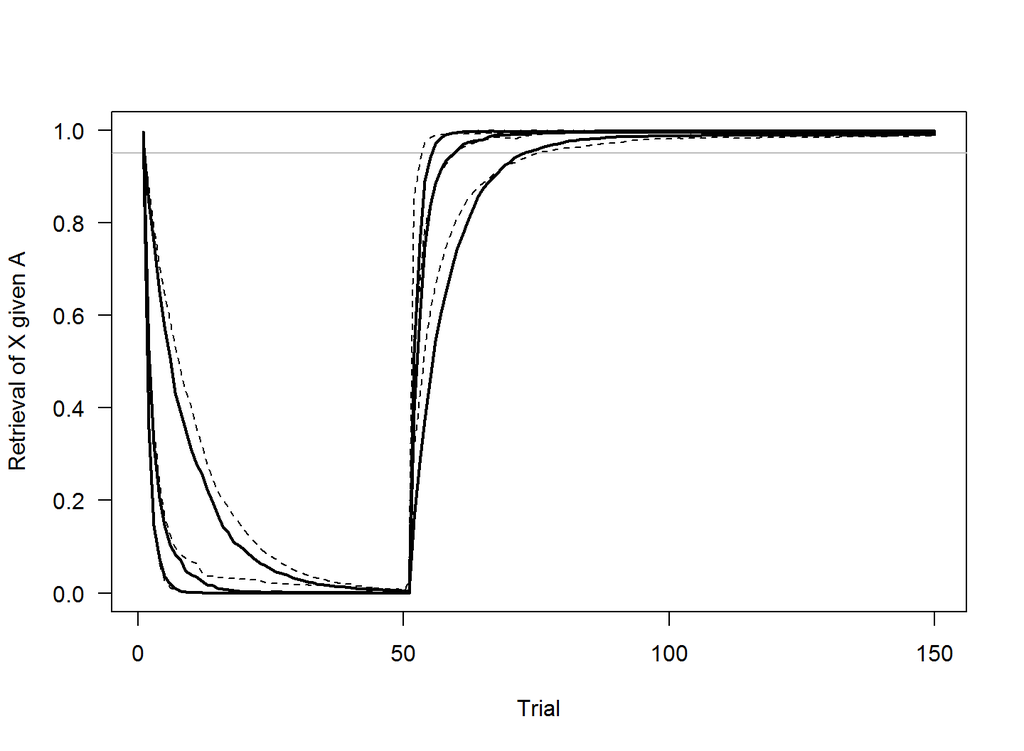

```r
reacquisition_results <- matrix(NA, ncol = 3, nrow = 2)

trails_to_master <- function(x) data.frame(n_trials = min(which(x >= 0.95)))

reacquisition_trial_counts <- reacquisition %>%
  group_by(L, V2) %>%
  do(trails_to_master(.[, 104:ncol(reacquisition)])) %>%
  group_by(L) %>%
  summarize(n_trials = mean_se(n_trials))

reacquisition_control_trial_counts <- reacquisition_control %>%
  group_by(L, V2) %>%
  do(trails_to_master(.[, 104:ncol(reacquisition_control)])) %>%
  group_by(L) %>%
  summarize(n_trials = mean_se(n_trials))

knitr::kable(
  bind_rows(Reacquition = reacquisition_trial_counts, Control = reacquisition_control_trial_counts, .id = "Condition") %>%
    spread(L, n_trials) %>%
    arrange(desc(Condition))
  , caption = "Reproduction of Table 1 based on Fortran implementation"
)
```

Reproduction of Table 1 based on Fortran implementation

| Condition | 0.33 | 0.67 | 1 |
| --- | --- | --- | --- |
| Reacquition | 22.12 (0.95) | 8.79 (0.88) | 5.67 (0.18) |
| Control | 24.5 (1.11) | 10.17 (0.58) | 3.17 (0.16) |

```r
plot(
  1:50
  , rep(0, 50)
  , pch = NA
  , ylim = c(0, 1)
  , lwd = 2.5
  , xlab = "Trial"
  , ylab = "Retrieval of X given A"
  , las = 1
)

abline(h = 0.95, col = "grey")

for(i in 1:length(p_encode)) {
  lines(colMeans(reacquisition_sim_results[(1:n_replications) + (i-1)*n_replications, 1:50]), lty = 2)
}

for(i in 1:length(p_encode)) {
  lines(colMeans(reacquisition_sim_results[(1:n_replications) + (i-1)*n_replications, 101:150]), lwd = 2)
}
```

```r
plot(
  1:50
  , rep(NA, 50)
  , ylim = c(0, 1)
  , lwd = 2.5
  , xlab = "Trial"
  , ylab = "Retrieval of X given A"
  , las = 1
)

abline(h = 0.95, col = "grey")

matlines(
  cbind(1:50, t(as.matrix(mean_reacquisition[, 102:151])))
  , col = "black"
  , lty = 1
  , lwd = 2
)

matlines(
  cbind(1:50, t(as.matrix(mean_reacquisition[, 2:51])))
  , col = "black"
  , lty = 2
)
```

# Section 2: Inhibition

Inhibition is observed, if after a learning phase a cue attenuates responding to an outcome.

## Direct test for conditioned inhibition

This associative learning protocol consists of two phases. The training phase mixes even trials in which, cue “A” is followed by outcome “X” and odd trials in which, a cue compound “AB” is presented without “X”. In the test phase retrieval of X|A and X|B is measured. As the simulation results shows, conditioned inhibition is observed. Retrieval of X|B is attenuated.

```r
knitr::opts_chunk$set(cache = TRUE)
```

```r
source("minerva-al.R")
source("supplementary_functions.R")
```

```r
# setup constant variables over all simulations
n_features <- 120
cue_features <- 1:100
a <- b  <- c <- d <- context <- outcome <- rep(0, n_features)

# setup stimuli
a[1:20] <- b [21:40] <- c[41:60] <- d[61:80] <- 1
context[81:100] <- 1
outcome[101:120] <- 1

# number of replications
n_replications <- 100

# learning rates
p_encode <- c(0.33, 0.67, 1)

# specify models
model = "Minerva AL"
```

```r
##############################################
### Direct Test for conditioned Inhibition ###
##############################################

# No further information about how to intermix A -> X and AB trials,
# therefore I used the odd/even solution

# specify events
training_ax_event <- a + context + outcome
training_ab_event <- a + b + context
probe_a <- a + context
probe_b <- b + context
probe_ab <-a + b + context

# setup trial number
n_trials <- 100

# prepare results object as matrix[n_trials, n_replications]
sim_results_xa <- matrix(0, ncol = n_replications, nrow = length(p_encode))
sim_results_xb <- matrix(0, ncol = n_replications, nrow = length(p_encode))
# specify object for normalized echo for every trial as 3D array[p_encode, n_trials, n_replications]
# with cells containing normalized echo vector
normalized_echos <- array(list(rep(NA, n_features)), dim = c(length(p_encode), n_trials, n_replications))
```

```r
#--------------- execute simulations--------------#

for (m in 1:length(model)){
  for (r in 1:n_replications) {
    for(i in 1:length(p_encode)) {
      # Memory is empty on first trial
      normalized_echo <- probe_memory(probe_a, NULL, cue_features, model = model[m])
      memory <- learn(
        normalized_echo
        , training_ax_event
        , p_encode[i]
        , NULL
        , model = model[m]
      )
      normalized_echos[[i,1,r]] <- normalized_echo

      # A -> X trials on every even number
      for(j in 2:(n_trials)) {
        if (j %% 2 == 0){
          normalized_echo <- probe_memory(probe_a, memory, cue_features, model = model[m])
          memory <- learn(
            normalized_echo
            , training_ax_event
            , p_encode[i]
            , memory
            , model = model[m]
          )
          normalized_echos[[i,j,r]] <- normalized_echo
        }
        else {
          # AB trials on every odd number
          normalized_echo <- probe_memory(probe_ab, memory, cue_features, model = model[m])
          memory <- learn(
            normalized_echo
            , training_ab_event
            , p_encode[i]
            , memory
            , model = model[m]
          )
          normalized_echos[[i,j,r]] <- normalized_echo
        }
      }
      # Test X|A and X|B after the Training trials
      normalized_echo_a <- probe_memory(probe_a, memory, cue_features, model = model[m])
      normalized_echo_b <- probe_memory(probe_b, memory, cue_features, model = model[m])
      sim_results_xa[i,r] <- expect_event(outcome = outcome, normalized_echo = normalized_echo_a)
      sim_results_xb[i,r] <- expect_event(outcome = outcome, normalized_echo = normalized_echo_b)
      }
    }
}


#-----calculate mean and standard error of results objects-----#

res_mat <- matrix(NA, nrow = 2, ncol = 3)

#compute means over replications
x <- rowMeans(sim_results_xa)
#compute standard errors over replications
y <- apply(sim_results_xa, 1, FUN = std_err)

for (i in 1:length(p_encode)){
  res_mat[1,i] <- table_fun(x[i], y[i])
}

#compute means over replications
x <- rowMeans(sim_results_xb)
#compute standard errors over replications
y <- apply(sim_results_xb, 1, FUN = std_err)

for (i in 1:length(p_encode)){
  res_mat[2,i] <- table_fun(x[i], y[i])
}

#Reproduction of Table 2
knitr::kable(cbind(Condition = c("X|A", "X|B"), res_mat), col.names = c("Condition", round(p_encode, 2)), caption = "Reproduction of Table 2")
```

Reproduction of Table 2

| Condition | 0.33 | 0.67 | 1 |
| --- | --- | --- | --- |
| X\|A | 0.94 (0) | 0.98 (0) | 0.95 (0) |
| X\|B | -0.2 (0) | -0.32 (0.01) | -0.6 (0.01) |

```r
#Table 2 as reported by Jamieson et al. (2012)
data <- c("0.93 (0.2)","0.97 (.01)","0.99 (.01)","-0.16 (.01)","-0.21 (.02)","-0.32 (.04)")
res_mat2 <- matrix(data = data, nrow = 2, ncol = 3, byrow = TRUE)

knitr::kable(cbind(Condition = c("X|A", "X|B"), res_mat2), col.names = c("Condition", round(p_encode, 2)), caption = "Table 2 as reported by Jamieson et al. (2012)")
```

Table 2 as reported by Jamieson et al. (2012)

| Condition | 0.33 | 0.67 | 1 |
| --- | --- | --- | --- |
| X\|A | 0.93 (0.2) | 0.97 (.01) | 0.99 (.01) |
| X\|B | -0.16 (.01) | -0.21 (.02) | -0.32 (.04) |

```r
#----- diagnostic plots ------#

# par(mfrow = c(2,2))
#
# # memory encoding of the outcome over the trials
# plot(
#   1:n_trials
#   , memory[, 101]
#   , type = "l"
#   , col = scales::alpha("black", 0.3)
#   , ylim = c(-2, 2)
#   , xlab = "Trial"
#   , ylab = "Feature encoding"
#   , main = "Features of outcome X"
#   , las = 1
# )
# for(i in 102:120) {
#   lines(
#     1:n_trials
#     , memory[, i]
#     , col = scales::alpha("black", 0.3)
#   )
# }
#
# # memory encoding of cue A over the trials
# plot(
#   1:n_trials
#   , memory[, 1]
#   , type = "l"
#   , col = scales::alpha("black", 0.3)
#   , ylim = c(-2, 2)
#   , xlab = "Trial"
#   , ylab = "Feature encoding"
#   , main = "Features of Cue A"
#   , las = 1
# )
# for(i in 2:20) {
#   lines(
#     1:n_trials
#     , memory[, i]
#     , col = scales::alpha("black", 0.3)
#   )
# }
#
# # memory encoding of cue B over the trials
# plot(
#   1:n_trials
#   , memory[, 21]
#   , type = "l"
#   , col = scales::alpha("black", 0.3)
#   , ylim = c(-2, 2)
#   , xlab = "Trial"
#   , ylab = "Feature encoding"
#   , main = "Features of Cue B"
#   , las = 1
# )
# for(i in 21:40) {
#   lines(
#     1:n_trials
#     , memory[, i]
#     , col = scales::alpha("black", 0.3)
#   )
# }
```

```r
# normalized echos over the trials

# libraries:
# library(ggplot2)
# library(gganimate)
#
#
# echos <- vector()
# for (i in 1:n_trials){
#   echos <- c(echos,normalized_echos[[3,i,1]])
# }
#
# data <- data.frame(Stimuli = c(1:n_features), Echo = echos, frame = rep(1:n_trials, each = n_features))
#
#
# # Make an animated boxplot
# p <- ggplot(data, aes(x=Stimuli, y=Echo, fill=Stimuli)) +
#   geom_bar(stat='identity') +
#   theme_bw() +
#   # gganimate specific bits:
#   transition_states(
#     states = frame,
#     transition_length = 1,
#     state_length = 1,
#     wrap = TRUE
#   )
#
# p <- p + ggtitle('Now showing Trial:{closest_state}')
# animate(p, nframes = 2*n_trials)
```

## Summation test for condition inhibition

This associative learning protocol consists of two phases. Phase 1 repeates the training phase of the direct test for inhibition protocol. In phase 2 a novel cue “C” is followed by “X”. After, Retrieval of X|BC, X|CD or X|C is tested. As the tables show cue “B” is a conditioned inhibitor, because retrieval of x|B is the lowest.

```r
# setup constant variables over all simulations
n_features <- 120
cue_features <- 1:100
a <- b  <- c <- d <- context <- outcome <- rep(0, n_features)

# setup stimuli
a[1:20] <- b [21:40] <- c[41:60] <- d[61:80] <- 1
context[81:100] <- 1
outcome[101:120] <- 1

# number of replications
n_replications <- 100

# learning rates
p_encode <- c(0.33, 0.67, 1)

# specify models
model = "Minerva AL"
```

```r
# specify events
training_ax_event <- a + context + outcome
training_ab_event <- a + b + context
training_cx_event <- c + context + outcome

probe_a <- a + context
probe_b <- b + context
probe_ab <- a + b + context
probe_bc <- b + c + context
probe_cd <- c + d + context
probe_c <- c + context

# setup trial number
n_trials <- 150

# prepare results object as matrix[n_trials, n_replications]
sim_results_xbc <- matrix(0, ncol = n_replications, nrow = length(p_encode))
sim_results_xcd <- matrix(0, ncol = n_replications, nrow = length(p_encode))
sim_results_xc <- matrix(0, ncol = n_replications, nrow = length(p_encode))
# specify object for normalized echo for every trial as 3D array[p_encode, n_trials, n_replications]
# with cells containing normalized echo vector
normalized_echos <- array(list(rep(NA, n_features)), dim = c(length(p_encode), n_trials, n_replications))
```

```r
#--------------- execute simulations--------------#

for (m in 1:length(model)){
  for (r in 1:n_replications) {
    for(i in 1:length(p_encode)) {
      # Memory is empty on first trial
      normalized_echo <- probe_memory(probe_ab, NULL, cue_features, model = model[m])
      memory <- learn(
        normalized_echo
        , training_ab_event
        , p_encode[i]
        , NULL
        , model = model[m]
      )
          normalized_echos[[i,1,r]] <- normalized_echo

       # A -> X trials on every even number
      for(j in 2:100) {
        if (j %% 2 == 0){
          normalized_echo <- probe_memory(probe_a, memory, cue_features, model = model[m])
          memory <- learn(
            normalized_echo
            , training_ax_event
            , p_encode[i]
            , memory
            , model = model[m]
          )
          normalized_echos[[i,j,r]] <- normalized_echo
        }
        else {
          # AB trials on every odd number
          normalized_echo <- probe_memory(probe_ab, memory, cue_features, model = model[m])
          memory <- learn(
            normalized_echo
            , training_ab_event
            , p_encode[i]
            , memory
            , model = model[m]
          )
          normalized_echos[[i,j,r]] <- normalized_echo
        }
      }
      # CX trials
      for(j in 101:150) {
        normalized_echo <- probe_memory(probe_c, memory, cue_features, model = model[m])
        memory <- learn(
          normalized_echo
          , training_cx_event
          , p_encode[i]
          , memory
          , model = model[m]
        )
        normalized_echos[[i,j,r]] <- normalized_echo
      }
      normalized_echo_bc <- probe_memory(probe_bc, memory, cue_features, model = model[m])
      normalized_echo_cd <- probe_memory(probe_cd, memory, cue_features, model = model[m])
      normalized_echo_c <- probe_memory(probe_c, memory, cue_features, model = model[m])
      sim_results_xbc[i,r] <- expect_event(outcome = outcome, normalized_echo = normalized_echo_bc)
      sim_results_xcd[i,r] <- expect_event(outcome = outcome, normalized_echo = normalized_echo_cd)
      sim_results_xc[i,r] <- expect_event(outcome = outcome, normalized_echo = normalized_echo_c)
    }
  }
}
```

```r
res_mat <- matrix(NA, nrow = 3, ncol = 3)

#compute means over replications
x <- rowMeans(sim_results_xbc)
#compute standard errors over replications
y <- apply(sim_results_xbc, 1, FUN = std_err)

for (i in 1:length(p_encode)){
  res_mat[1,i] <- table_fun(x[i], y[i])
}

#compute means over replications
x <- rowMeans(sim_results_xcd)
#compute standard errors over replications
y <- apply(sim_results_xcd, 1, FUN = std_err)

for (i in 1:length(p_encode)){
  res_mat[2,i] <- table_fun(x[i], y[i])
}

#compute means over replications
x <- rowMeans(sim_results_xc)
#compute standard errors over replications
y <- apply(sim_results_xc, 1, FUN = std_err)

for (i in 1:length(p_encode)){
  res_mat[3,i] <- table_fun(x[i], y[i])
}

#Reproduction of Table 3
knitr::kable(cbind(Condition = c("Summation", "Control (1)", "Control (2)"), res_mat), col.names = c("Condition", round(p_encode, 2)), caption = "Reproduction of Table 3")
```

Reproduction of Table 3

| Condition | 0.33 | 0.67 | 1 |
| --- | --- | --- | --- |
| Summation | 0.13 (0.01) | 0.19 (0.02) | -0.34 (0.04) |
| Control (1) | 0.91 (0.01) | 0.92 (0.01) | 0.91 (0.01) |
| Control (2) | 0.97 (0) | 0.99 (0) | 1 (0) |

```r
#Table 3 as reported by Jamieson et al. (2012)
data <- c("0.13 (.02)","0.18 (.02)","0.05 (.07)","0.93 (.01)","0.92 (.01)","0.89 (.02)", "0.99 (.00)", "0.99 (.00)", "1.0 (.00)")
res_mat2 <- matrix(data = data, nrow = 3, ncol = 3, byrow = TRUE)

knitr::kable(cbind(Condition = c("Summation", "Control (1)", "Control (2)"), res_mat2), col.names = c("Condition", round(p_encode, 2)), caption = "Table 3 as reported by Jamieson et al. (2012)")
```

Table 3 as reported by Jamieson et al. (2012)

| Condition | 0.33 | 0.67 | 1 |
| --- | --- | --- | --- |
| Summation | 0.13 (.02) | 0.18 (.02) | 0.05 (.07) |
| Control (1) | 0.93 (.01) | 0.92 (.01) | 0.89 (.02) |
| Control (2) | 0.99 (.00) | 0.99 (.00) | 1.0 (.00) |

```r
#----- diagnostic plots ------#

# par(mfrow=c(2,2))
#
# # memory encoding of the outcome over the trials
# plot(
#   1:n_trials
#   , memory[, 101]
#   , type = "l"
#   , col = scales::alpha("black", 0.3)
#   , ylim = c(-2, 2)
#   , xlab = "Trial"
#   , ylab = "Feature encoding"
#   , main = "Features of outcome X"
#   , las = 1
# )
# for(i in 102:120) {
#   lines(
#     1:n_trials
#     , memory[, i]
#     , col = scales::alpha("black", 0.3)
#   )
# }
#
# # memory encoding of cue A over the trials
# plot(
#   1:n_trials
#   , memory[, 1]
#   , type = "l"
#   , col = scales::alpha("black", 0.3)
#   , ylim = c(-2, 2)
#   , xlab = "Trial"
#   , ylab = "Feature encoding"
#   , main = "Features of Cue A"
#   , las = 1
# )
# for(i in 2:20) {
#   lines(
#     1:n_trials
#     , memory[, i]
#     , col = scales::alpha("black", 0.3)
#   )
# }
#
# # memory encoding of cue B over the trials
# plot(
#   1:n_trials
#   , memory[, 21]
#   , type = "l"
#   , col = scales::alpha("black", 0.3)
#   , ylim = c(-2, 2)
#   , xlab = "Trial"
#   , ylab = "Feature encoding"
#   , main = "Features of Cue B"
#   , las = 1
# )
# for(i in 21:40) {
#   lines(
#     1:n_trials
#     , memory[, i]
#     , col = scales::alpha("black", 0.3)
#   )
# }
#
# # memory encoding of cue C over the trials
# plot(
#   1:n_trials
#   , memory[, 41]
#   , type = "l"
#   , col = scales::alpha("black", 0.3)
#   , ylim = c(-2, 2)
#   , xlab = "Trial"
#   , ylab = "Feature encoding"
#   , main = "Features of Cue C"
#   , las = 1
# )
# for(i in 41:60) {
#   lines(
#     1:n_trials
#     , memory[, i]
#     , col = scales::alpha("black", 0.3)
#   )
# }
```

```r
# normalized echos over the trials

# libraries:
# library(ggplot2)
# library(gganimate)
#
#
# echos <- vector()
# for (i in 1:n_trials){
#   echos <- c(echos,normalized_echos[[3,i,1]])
# }
#
# data <- data.frame(Stimuli = c(1:n_features), Echo = echos, frame = rep(1:n_trials, each = n_features))
#
#
# # Make an animated boxplot
# p <- ggplot(data, aes(x=Stimuli, y=Echo, fill=Stimuli)) +
#   geom_bar(stat='identity') +
#   theme_bw() +
#   # gganimate specific bits:
#   transition_states(
#     states = frame,
#     transition_length = 1,
#     state_length = 1,
#     wrap = TRUE
#   )
#
# p <- p + ggtitle('Now showing Trial:{closest_state}')
# animate(p, nframes = 2*n_trials)
```

## Retardation test for conditioned inhibition

```r
# setup constant variables over all simulations
n_features <- 120
cue_features <- 1:100
a <- b  <- c <- d <- context <- outcome <- rep(0, n_features)

# setup stimuli
a[1:20] <- b [21:40] <- c[41:60] <- d[61:80] <- 1
context[81:100] <- 1
outcome[101:120] <- 1

# number of replications
n_replications <- 100

# learning rates
p_encode <- c(0.33, 0.67, 1)

# specify models
model = "Minerva AL"
```

```r
# specify events
training_ax_event <- a + context + outcome
training_ab_event <- a + b + context
test_bcx_event <- b + c + context + outcome
test_cx_event <- c + context + outcome

probe_a <- a + context
probe_ab <- a + b + context
probe_bc <- b + c + context
probe_c <- c + context

# setup trial number
n_trials <- 200

# prepare results object as 3D array[p_encode, n_trials, n_replications]
sim_results_exp <- array(NA, c(length(p_encode), n_trials, n_replications))
sim_results_control <- array(NA, c(length(p_encode), n_trials, n_replications))
# specify object for normalized echo for every trial as 3D array[p_encode, n_trials, n_replications]
# with cells containing normalized echo vector
normalized_echos_exp <- array(list(rep(NA, n_features)), dim = c(length(p_encode), n_trials, n_replications))
normalized_echos_control <- array(list(rep(NA, n_features)), dim = c(length(p_encode), n_trials, n_replications))
```

```r
#------------------------Experimental Condition--------------------------------#

for (m in 1:length(model)){
  for (r in 1:n_replications) {
    for(i in 1:length(p_encode)) {
      # Memory is empty on first trial
      normalized_echo <- probe_memory(probe_ab, NULL, cue_features, model = model[m])
      memory <- learn(
        normalized_echo
        , training_ab_event
        , p_encode[i]
        , NULL
        , model = model[m]
      )
          normalized_echos_exp[[i,1,r]] <- normalized_echo

       # A -> X trials on every even number
      for(j in 2:100) {
        if (j %% 2 == 0){
          normalized_echo <- probe_memory(probe_a, memory, cue_features, model = model[m])
          memory <- learn(
            normalized_echo
            , training_ax_event
            , p_encode[i]
            , memory
            , model = model[m]
          )
          normalized_echos_exp[[i,j,r]] <- normalized_echo
        }
        else {
          # AB trials on every odd number
          normalized_echo <- probe_memory(probe_ab, memory, cue_features, model = model[m])
          memory <- learn(
            normalized_echo
            , training_ab_event
            , p_encode[i]
            , memory
            , model = model[m]
          )
          normalized_echos_exp[[i,j,r]] <- normalized_echo
        }
      }
      # BC -> X trials
      for(j in 101:200) {
        normalized_echo <- probe_memory(probe_bc, memory, cue_features, model = model[m])
        expectancy <- expect_event(outcome, normalized_echo)
        memory <- learn(
          normalized_echo
          , test_bcx_event
          , p_encode[i]
          , memory
          , model = model[m]
        )
        sim_results_exp[[i,j,r]] <- expectancy
        normalized_echos_exp[[i,j,r]] <- normalized_echo
      }
    }
  }
}

#-----calculate mean and standard error of results objects-----#
sim_results_exp <- sim_results_exp[,101:200,]
divide_by_n_rep <- function(x, n_rep = n_replications){x/n_rep}
# Sum of expectancies for each trial over all replications
mean_sim_results_exp <- apply(sim_results_exp, c(1,2), FUN = sum)
# Mean of expectancies for each trial over all replications
mean_sim_results_exp <- apply(mean_sim_results_exp, c(1,2), FUN = divide_by_n_rep)
# critical trial until x|cue >= 0.95 in each replication for every learning rate
crit_trials <- apply(sim_results_exp, c(1,3), FUN = find_crit_trial)
# se of critical trials until x|cue >= 0.95 in each replication for every learning rate
std_error <- apply(crit_trials, 1, FUN = std_err)
```

```r
res_mat <- matrix(NA, nrow = 2, ncol = 3)

#compute means over replications
x <- rowMeans(crit_trials)
#compute standard errors over replications
y <- std_error

for (i in 1:length(p_encode)){
  res_mat[1,i] <- table_fun(x[i], y[i])
}
```

```r
# -------------------- Diagnostic Plots --------------------------------------#

# par(mfrow = c(2,2))
#
# # memory encoding of the outcome over the trials
# plot(
#   1:200
#   , memory[, 101]
#   , type = "l"
#   , col = scales::alpha("black", 0.3)
#   , ylim = c(-2, 2)
#   , xlab = "Trial"
#   , ylab = "Feature encoding"
#   , main = "Features of outcome X"
#   , las = 1
# )
# for(i in 102:120) {
#   lines(
#     1:200
#     , memory[, i]
#     , col = scales::alpha("black", 0.3)
#   )
# }
#
# # memory encoding of cue A over the trials
# plot(
#   1:200
#   , memory[, 1]
#   , type = "l"
#   , col = scales::alpha("black", 0.3)
#   , ylim = c(-2, 2)
#   , xlab = "Trial"
#   , ylab = "Feature encoding"
#   , main = "Features of Cue A"
#   , las = 1
# )
# for(i in 2:20) {
#   lines(
#     1:200
#     , memory[, i]
#     , col = scales::alpha("black", 0.3)
#   )
# }
#
# # memory encoding of cue B over the trials
# plot(
#   1:n_trials
#   , memory[, 21]
#   , type = "l"
#   , col = scales::alpha("black", 0.3)
#   , ylim = c(-2, 2)
#   , xlab = "Trial"
#   , ylab = "Feature encoding"
#   , main = "Features of Cue B"
#   , las = 1
# )
# for(i in 22:40) {
#   lines(
#     1:n_trials
#     , memory[, i]
#     , col = scales::alpha("black", 0.3)
#   )
# }
#
# # memory encoding of cue C over the trials
# plot(
#   1:n_trials
#   , memory[, 41]
#   , type = "l"
#   , col = scales::alpha("black", 0.3)
#   , ylim = c(-2, 2)
#   , xlab = "Trial"
#   , ylab = "Feature encoding"
#   , main = "Features of Cue C"
#   , las = 1
# )
# for(i in 42:60) {
#   lines(
#     1:n_trials
#     , memory[, i]
#     , col = scales::alpha("black", 0.3)
#   )
# }
```

```r
# normalized echos over the trials

# echos <- vector()
# for (i in 1:n_trials){
#   echos <- c(echos,normalized_echos_exp[[3,i,1]])
# }
#
# data <- data.frame(Stimuli = c(1:n_features), Echo = echos, frame = rep(1:n_trials, each = n_features))
#
#
# # Make an animated boxplot
# p <- ggplot(data, aes(x=Stimuli, y=Echo, fill=Stimuli)) +
#   geom_bar(stat='identity') +
#   theme_bw() +
#   # gganimate specific bits:
#   transition_states(
#     states = frame,
#     transition_length = 1,
#     state_length = 1,
#     wrap = TRUE
#   )
#
# p <- p + ggtitle('Now showing Trial:{closest_state}')
# animate(p, nframes = 2*n_trials)
```

```r
#------------------------Control Condition--------------------------------#

for (m in 1:length(model)){
  for (r in 1:n_replications) {
    for(i in 1:length(p_encode)) {
      # Memory is empty on first trial
      normalized_echo <- probe_memory(probe_ab, NULL, cue_features, model = model[m])
      memory <- learn(
        normalized_echo
        , training_ab_event
        , p_encode[i]
        , NULL
        , model = model[m]
      )
          normalized_echos_control[[i,1,r]] <- normalized_echo

       # A -> X trials on every even number
      for(j in 2:100) {
        if (j %% 2 == 0){
          normalized_echo <- probe_memory(probe_a, memory, cue_features, model = model[m])
          memory <- learn(
            normalized_echo
            , training_ax_event
            , p_encode[i]
            , memory
            , model = model[m]
          )
          normalized_echos_control[[i,j,r]] <- normalized_echo
        }
        else {
          # AB trials on every odd number
          normalized_echo <- probe_memory(probe_ab, memory, cue_features, model = model[m])
          memory <- learn(
            normalized_echo
            , training_ab_event
            , p_encode[i]
            , memory
            , model = model[m]
          )
          normalized_echos_control[[i,j,r]] <- normalized_echo
        }
      }
      # C -> X trials
      for(j in 101:200) {
        normalized_echo <- probe_memory(probe_c, memory, cue_features, model = model[m])
        expectancy <- expect_event(outcome, normalized_echo)
        memory <- learn(
          normalized_echo
          , test_cx_event
          , p_encode[i]
          , memory
          , model = model[m]
        )
        sim_results_control[[i,j,r]] <- expectancy
        normalized_echos_control[[i,j,r]] <- normalized_echo
      }
    }
  }
}

#-----calculate mean and standard error of results objects-----#
sim_results_control <- sim_results_control[,101:200,]
divide_by_n_rep <- function(x, n_rep = n_replications){x/n_rep}
# Sum of expectancies for each trial over all replications
mean_sim_results_control <- apply(sim_results_control, c(1,2), FUN = sum)
# Mean of expectancies for each trial over all replications
mean_sim_results_control <- apply(mean_sim_results_control, c(1,2), FUN = divide_by_n_rep)
# critical trial until x|cue >= 0.95 in each replication for every learning rate
crit_trials <- apply(sim_results_control, c(1,3), FUN = find_crit_trial)
# se of critical trials until x|cue >= 0.95 in each replication for every learning rate
std_error <- apply(crit_trials, 1, FUN = std_err)
```

```r
#compute means over replications
x <- rowMeans(crit_trials)
#compute standard errors over replications
y <- std_error

for (i in 1:length(p_encode)){
  res_mat[2,i] <- table_fun(x[i], y[i])
}

#Reproduction of Table 4
knitr::kable(cbind(Condition = c("Experimental", "Control"), res_mat), col.names = c("Condition", round(p_encode, 2)), caption = "Reproduction of Table 4")
```

Reproduction of Table 4

| Condition | 0.33 | 0.67 | 1 |
| --- | --- | --- | --- |
| Experimental | 39.26 (0.98) | 15.76 (0.54) | 7.63 (0.43) |
| Control | 23.77 (0.72) | 8.58 (0.39) | 3.4 (0.1) |

```r
#Table 4 as reported by Jamieson et al. (2012)
data <- c("46.6 (3.7)","16.3 (0.9)","5.6 (0.7)","29.4 (1.5)","13.2 (1.0)","4.2 (0.2)")
res_mat2 <- matrix(data = data, nrow = 2, ncol = 3, byrow = TRUE)

knitr::kable(cbind(Condition = c("Experimental", "Control"), res_mat2), col.names = c("Condition", round(p_encode, 2)), caption = "Table 4 as reported by Jamieson et al. (2012)")
```

Table 4 as reported by Jamieson et al. (2012)

| Condition | 0.33 | 0.67 | 1 |
| --- | --- | --- | --- |
| Experimental | 46.6 (3.7) | 16.3 (0.9) | 5.6 (0.7) |
| Control | 29.4 (1.5) | 13.2 (1.0) | 4.2 (0.2) |

```r
# -------------------- Diagnostic Plots --------------------------------------#

# par(mfrow = c(2,2))
#
# # memory encoding of the outcome over the trials
# plot(
#   1:200
#   , memory[, 101]
#   , type = "l"
#   , col = scales::alpha("black", 0.3)
#   , ylim = c(-2, 2)
#   , xlab = "Trial"
#   , ylab = "Feature encoding"
#   , main = "Features of outcome X"
#   , las = 1
# )
# for(i in 102:120) {
#   lines(
#     1:200
#     , memory[, i]
#     , col = scales::alpha("black", 0.3)
#   )
# }
#
# # memory encoding of cue A over the trials
# plot(
#   1:200
#   , memory[, 1]
#   , type = "l"
#   , col = scales::alpha("black", 0.3)
#   , ylim = c(-2, 2)
#   , xlab = "Trial"
#   , ylab = "Feature encoding"
#   , main = "Features of Cue A"
#   , las = 1
# )
# for(i in 2:20) {
#   lines(
#     1:200
#     , memory[, i]
#     , col = scales::alpha("black", 0.3)
#   )
# }
#
# # memory encoding of cue B over the trials
# plot(
#   1:n_trials
#   , memory[, 21]
#   , type = "l"
#   , col = scales::alpha("black", 0.3)
#   , ylim = c(-2, 2)
#   , xlab = "Trial"
#   , ylab = "Feature encoding"
#   , main = "Features of Cue B"
#   , las = 1
# )
# for(i in 22:40) {
#   lines(
#     1:n_trials
#     , memory[, i]
#     , col = scales::alpha("black", 0.3)
#   )
# }
#
# # memory encoding of cue C over the trials
# plot(
#   1:n_trials
#   , memory[, 41]
#   , type = "l"
#   , col = scales::alpha("black", 0.3)
#   , ylim = c(-2, 2)
#   , xlab = "Trial"
#   , ylab = "Feature encoding"
#   , main = "Features of Cue C"
#   , las = 1
# )
# for(i in 42:60) {
#   lines(
#     1:n_trials
#     , memory[, i]
#     , col = scales::alpha("black", 0.3)
#   )
# }
```

```r
# normalized echos over the trials

# echos <- vector()
# for (i in 1:n_trials){
#   echos <- c(echos,normalized_echos_control[[3,i,1]])
# }
#
# data <- data.frame(Stimuli = c(1:n_features), Echo = echos, frame = rep(1:n_trials, each = n_features))
#
#
# # Make an animated boxplot
# p <- ggplot(data, aes(x=Stimuli, y=Echo, fill=Stimuli)) +
#   geom_bar(stat='identity') +
#   theme_bw() +
#   # gganimate specific bits:
#   transition_states(
#     states = frame,
#     transition_length = 1,
#     state_length = 1,
#     wrap = TRUE
#  )

# p <- p + ggtitle('Now showing Trial:{closest_state}')
# animate(p, nframes = 2*n_trials)
```

## External inhibition

```r
knitr::opts_chunk$set(cache = TRUE)
```

```r
source("minerva-al.R")
source("supplementary_functions.R")
```

```r
# setup constant variables over all simulations
n_features <- 120
cue_features <- 1:100
a <- b  <- c <- d <- context <- outcome <- rep(0, n_features)

# setup stimuli
a[1:20] <- b [21:40] <- c[41:60] <- d[61:80] <- 1
context[81:100] <- 1
outcome[101:120] <- 1

# number of replications
n_replications <- 100

# learning rates
p_encode <- c(0.33, 0.67, 1)

# specify models
model = "Minerva AL"
```

```r
# specify events
training_ax_event <- a + context + outcome

# specify probe
probe_a <- a + context
probe_ab <- a + b + context

# setup trial number
n_trials <- 50

# prepare results object as a matrix[p_encode, n_replications]
sim_results_xab <- matrix(0, ncol = n_replications, nrow = length(p_encode))
sim_results_xa <- matrix(0, ncol = n_replications, nrow = length(p_encode))
# specify object for normalized echo for every trial as 3D array[p_encode, n_trials, n_replications]
# with cells containing normalized echo vector
normalized_echos_ext_inh <- array(list(rep(NA, n_features)), dim = c(length(p_encode), n_trials+1, n_replications))
normalized_echos_control <- array(list(rep(NA, n_features)), dim = c(length(p_encode), n_trials+1, n_replications))
```

```r
#-----------------------External Inhibition Condition--------------------------------#

for (m in 1:length(model)){
    for (r in 1:n_replications) {
      for(i in 1:length(p_encode)) {
        # Memory is empty on first trial
        normalized_echo <- probe_memory(probe_a, NULL, cue_features, model = model[m])
        memory <- learn(
          normalized_echo
          , training_ax_event
          , p_encode[i]
          , NULL
          , model = model[m]
        )
        normalized_echos_ext_inh[[i,1,r]] <- normalized_echo

        # A -> X trials
        for(j in 2:n_trials) {
          normalized_echo <- probe_memory(probe_a, memory, cue_features, model = model[m])
          memory <- learn(
            normalized_echo
            , training_ax_event
            , p_encode[i]
            , memory
            , model = model[m]
          )
        normalized_echos_ext_inh[[i,j,r]] <- normalized_echo
        }
        normalized_echo_ab <- probe_memory(probe_ab, memory, cue_features, model = model[m])
        normalized_echos_ext_inh[[i,j+1,r]] <- normalized_echo_ab
        sim_results_xab[i,r] <- expect_event(outcome, normalized_echo_ab)
      }
    }
  }
```

```r
res_mat <- matrix(NA, nrow = 2, ncol = 3)

#compute means over replications
x <- rowMeans(sim_results_xab)
#compute standard errors over replications
y <- apply(sim_results_xab, 1, FUN = std_err)

for (i in 1:length(p_encode)){
  res_mat[1,i] <- table_fun(x[i], y[i])
}
```

```r
#----- diagnostic plots ------#

# par(mfrow=c(2,2))
#
# # memory encoding of the outcome over the trials
# plot(
#   1:n_trials
#   , memory[, 101]
#   , type = "l"
#   , col = scales::alpha("black", 0.3)
#   , ylim = c(-2, 2)
#   , xlab = "Trial"
#   , ylab = "Feature encoding"
#   , main = "Features of outcome X"
#   , las = 1
# )
# for(i in 102:120) {
#   lines(
#     1:n_trials
#     , memory[, i]
#     , col = scales::alpha("black", 0.3)
#   )
# }
#
# # memory encoding of cue A over the trials
# plot(
#   1:n_trials
#   , memory[, 1]
#   , type = "l"
#   , col = scales::alpha("black", 0.3)
#   , ylim = c(-2, 2)
#   , xlab = "Trial"
#   , ylab = "Feature encoding"
#   , main = "Features of Cue A"
#   , las = 1
# )
# for(i in 2:20) {
#   lines(
#     1:n_trials
#     , memory[, i]
#     , col = scales::alpha("black", 0.3)
#   )
# }
#
# # memory encoding of cue B over the trials
# plot(
#   1:n_trials
#   , memory[, 21]
#   , type = "l"
#   , col = scales::alpha("black", 0.3)
#   , ylim = c(-2, 2)
#   , xlab = "Trial"
#   , ylab = "Feature encoding"
#   , main = "Features of Cue B"
#   , las = 1
# )
# for(i in 21:40) {
#   lines(
#     1:n_trials
#     , memory[, i]
#     , col = scales::alpha("black", 0.3)
#   )
# }
```

```r
# normalized echos over the trials

# libraries:
# library(ggplot2)
# library(gganimate)
#
#
# echos <- vector()
# for (i in 1:n_trials){
#   echos <- c(echos,normalized_echos_ext_inh[[3,i,1]])
# }
#
# data <- data.frame(Stimuli = c(1:n_features), Echo = echos, frame = rep(1:n_trials, each = n_features))
#
#
# # Make an animated boxplot
# p <- ggplot(data, aes(x=Stimuli, y=Echo, fill=Stimuli)) +
#   geom_bar(stat='identity') +
#   theme_bw() +
#   # gganimate specific bits:
#   transition_states(
#     states = frame,
#     transition_length = 1,
#     state_length = 1,
#     wrap = TRUE
#   )
#
# p <- p + ggtitle('Now showing Trial:{closest_state}')
# animate(p, nframes = 2*n_trials+2)
```

```r
#-----------------------Control Condition--------------------------------#

for (m in 1:length(model)){
    for (r in 1:n_replications) {
      for(i in 1:length(p_encode)) {
        # Memory is empty on first trial
        normalized_echo <- probe_memory(probe_a, NULL, cue_features, model = model[m])
        memory <- learn(
          normalized_echo
          , training_ax_event
          , p_encode[i]
          , NULL
          , model = model[m]
        )
        normalized_echos_control[[i,1,r]] <- normalized_echo

        # A -> X trials
        for(j in 2:n_trials) {
          normalized_echo <- probe_memory(probe_a, memory, cue_features, model = model[m])
          memory <- learn(
            normalized_echo
            , training_ax_event
            , p_encode[i]
            , memory
            , model = model[m]
          )
        normalized_echos_control[[i,j,r]] <- normalized_echo
        }
        normalized_echo_a <- probe_memory(probe_a, memory, cue_features, model = model[m])
        normalized_echos_control[[i,j+1,r]] <- normalized_echo_a
        sim_results_xa[i,r] <- expect_event(outcome, normalized_echo_a)
      }
    }
  }
```

```r
#compute means over replications
x <- rowMeans(sim_results_xa)
#compute standard errors over replications
y <- apply(sim_results_xa, 1, FUN = std_err)

for (i in 1:length(p_encode)){
  res_mat[2,i] <- table_fun(x[i], y[i])
}

knitr::kable(cbind(Condition = c("External Inhibition", "Control"), res_mat), col.names = c("Condition", round(p_encode, 2)), caption = "Reproduction of Table 5")
```

Reproduction of Table 5

| Condition | 0.33 | 0.67 | 1 |
| --- | --- | --- | --- |
| External Inhibition | 0.84 (0.01) | 0.84 (0.01) | 0.87 (0.01) |
| Control | 0.98 (0) | 1 (0) | 1 (0) |

```r
#Table 5 as reported by Jamieson et al. (2012)
data <- c("0.80 (.02)","0.85 (.02)","0.90 (.02)","0.98 (.00)","0.99 (.00)","1.0 (.00)")
res_mat2 <- matrix(data = data, nrow = 2, ncol = 3, byrow = TRUE)

knitr::kable(cbind(Condition = c("External Inhibition", "Control"), res_mat2), col.names = c("Condition", round(p_encode, 2)), caption = "Table 5 as reported by Jamieson et al. (2012)")
```

Table 5 as reported by Jamieson et al. (2012)

| Condition | 0.33 | 0.67 | 1 |
| --- | --- | --- | --- |
| External Inhibition | 0.80 (.02) | 0.85 (.02) | 0.90 (.02) |
| Control | 0.98 (.00) | 0.99 (.00) | 1.0 (.00) |

```r
#----- diagnostic plots ------#

# par(mfrow=c(2,2))
#
# # memory encoding of the outcome over the trials
# plot(
#   1:n_trials
#   , memory[, 101]
#   , type = "l"
#   , col = scales::alpha("black", 0.3)
#   , ylim = c(-2, 2)
#   , xlab = "Trial"
#   , ylab = "Feature encoding"
#   , main = "Features of outcome X"
#   , las = 1
# )
# for(i in 102:120) {
#   lines(
#     1:n_trials
#     , memory[, i]
#     , col = scales::alpha("black", 0.3)
#   )
# }
#
# # memory encoding of cue A over the trials
# plot(
#   1:n_trials
#   , memory[, 1]
#   , type = "l"
#   , col = scales::alpha("black", 0.3)
#   , ylim = c(-2, 2)
#   , xlab = "Trial"
#   , ylab = "Feature encoding"
#   , main = "Features of Cue A"
#   , las = 1
# )
# for(i in 2:20) {
#   lines(
#     1:n_trials
#     , memory[, i]
#     , col = scales::alpha("black", 0.3)
#   )
# }
#
# # memory encoding of cue B over the trials
# plot(
#   1:n_trials
#   , memory[, 21]
#   , type = "l"
#   , col = scales::alpha("black", 0.3)
#   , ylim = c(-2, 2)
#   , xlab = "Trial"
#   , ylab = "Feature encoding"
#   , main = "Features of Cue B"
#   , las = 1
# )
# for(i in 21:40) {
#   lines(
#     1:n_trials
#     , memory[, i]
#     , col = scales::alpha("black", 0.3)
#   )
# }
```

```r
# normalized echos over the trials

# libraries:
# library(ggplot2)
# library(gganimate)
#
#
# echos <- vector()
# for (i in 1:n_trials){
#   echos <- c(echos,normalized_echos_control[[3,i,1]])
# }
#
# data <- data.frame(Stimuli = c(1:n_features), Echo = echos, frame = rep(1:n_trials, each = n_features))
#
#
# # Make an animated boxplot
# p <- ggplot(data, aes(x=Stimuli, y=Echo, fill=Stimuli)) +
#   geom_bar(stat='identity') +
#   theme_bw() +
#   # gganimate specific bits:
#   transition_states(
#     states = frame,
#     transition_length = 1,
#     state_length = 1,
#     wrap = TRUE
#   )
#
# p <- p + ggtitle('Now showing Trial:{closest_state}')
# animate(p, nframes = 2*n_trials+2)
```

## Latent inhibition

This associative learning protocol consists of three conditions each with a pretraining phase, in which cue “A” is presented, and a test phase, where mean trials to achieve a criterion of X|A > .95 is measured. In the 0 pretrials condition, there is no pretraining, only the test phase. In the 10 and 30 pretrials conditions, there are 10 or 30 trials of pretraining, respectively. Latent inhition is observed when preexposure to cue “A” slows subsequent learning with it. As expected, the tables show that with higher number of pretrials Minerva AL needs more trials to achieve the criterion value.

```r
# setup constant variables over all simulations
n_features <- 120
cue_features <- 1:100
a <- b  <- c <- d <- context <- outcome <- rep(0, n_features)

# setup stimuli
a[1:20] <- b [21:40] <- c[41:60] <- d[61:80] <- 1
context[81:100] <- 1
outcome[101:120] <- 1

# number of replications
n_replications <- 100

# learning rates
p_encode <- c(0.33, 0.67, 1)

# specify models
model = "Minerva AL"
```

```r
# specify events
training_a_event <- a + context
test_ax_event <- a + context + outcome

# specify probe
probe_a <- a + context

# setup trial number
n_trials <- 200

# prepare results object as 3D array[p_encode, n_trials, n_replications]
sim_results_0_pretrials <- array(NA, c(length(p_encode), n_trials, n_replications))
sim_results_10_pretrials <- array(NA, c(length(p_encode), n_trials, n_replications))
sim_results_30_pretrials <- array(NA, c(length(p_encode), n_trials, n_replications))
# specify object for normalized echo for every trial as 3D array[p_encode, n_trials, n_replications]
# with cells containing normalized echo vector
normalized_echos_0_pretrials <- array(list(rep(NA, n_features)), dim = c(length(p_encode), n_trials, n_replications))
normalized_echos_10_pretrials <- array(list(rep(NA, n_features)), dim = c(length(p_encode), n_trials, n_replications))
normalized_echos_30_pretrials <- array(list(rep(NA, n_features)), dim = c(length(p_encode), n_trials, n_replications))
```

```r
#-----------------------0 Pretrials Condition--------------------------------#

for (m in 1:length(model)){
  for (r in 1:n_replications) {
    for(i in 1:length(p_encode)) {
      # Memory is empty on first trial
      normalized_echo <- probe_memory(probe_a, NULL, cue_features, model = model[m])
      expectancy <- expect_event(outcome, normalized_echo)
      memory <- learn(
        normalized_echo
        , test_ax_event
        , p_encode[i]
        , NULL
        , model = model[m]
      )
      sim_results_0_pretrials[[i,1,r]] <- expectancy
      normalized_echos_0_pretrials[[i,1,r]] <- normalized_echo

       # A -> X trials
      for(j in 2:n_trials) {
          normalized_echo <- probe_memory(probe_a, memory, cue_features, model = model[m])
          expectancy <- expect_event(outcome, normalized_echo)
          memory <- learn(
            normalized_echo
            , test_ax_event
            , p_encode[i]
            , memory
            , model = model[m]
          )
          sim_results_0_pretrials[[i,j,r]] <- expectancy
          normalized_echos_0_pretrials[[i,j,r]] <- normalized_echo
      }
    }
  }
}

#-----calculate mean and standard error of results objects-----#
divide_by_n_rep <- function(x, n_rep = n_replications){x/n_rep}
# Sum of expectancies for each trial over all replications
mean_sim_results_0_pretrials <- apply(sim_results_0_pretrials, c(1,2), FUN = sum)
# Mean of expectancies for each trial over all replications
mean_sim_results_0_pretrials <- apply(mean_sim_results_0_pretrials, c(1,2), FUN = divide_by_n_rep)
# critical trial until x|cue >= 0.95 in each replication for every learning rate
crit_trials_0_pretrials <- apply(sim_results_0_pretrials, c(1,3), FUN = find_crit_trial)
# se of critical trials until x|cue >= 0.95 in each replication for every learning rate
std_error_0_pretrials <- apply(crit_trials_0_pretrials, 1, FUN = std_err)
```

```r
res_mat <- matrix(NA, nrow = 3, ncol = 3)

#compute means over replications
x <- rowMeans(crit_trials_0_pretrials)
#compute standard errors over replications
y <- std_error_0_pretrials

for (i in 1:length(p_encode)){
  res_mat[1,i] <- table_fun(x[i], y[i])
}
```

```r
# --------------------- Diagnostic Plots --------------------------------------#

# par(mfrow=c(1,2))
#
# # memory encoding of the outcome over the trials
# plot(
#   1:n_trials
#   , memory[, 101]
#   , type = "l"
#   , col = scales::alpha("black", 0.3)
#   , ylim = c(-2, 2)
#   , xlab = "Trial"
#   , ylab = "Feature encoding"
#   , main = "Features of outcome X"
#   , las = 1
# )
# for(i in 102:120) {
#   lines(
#     1:n_trials
#     , memory[, i]
#     , col = scales::alpha("black", 0.3)
#   )
# }
#
# # memory encoding of cue A over the trials
# plot(
#   1:n_trials
#   , memory[, 1]
#   , type = "l"
#   , col = scales::alpha("black", 0.3)
#   , ylim = c(-2, 2)
#   , xlab = "Trial"
#   , ylab = "Feature encoding"
#   , main = "Features of Cue A"
#   , las = 1
# )
# for(i in 2:20) {
#   lines(
#     1:n_trials
#     , memory[, i]
#     , col = scales::alpha("black", 0.3)
#   )
# }
```

```r
# normalized echos over the trials

# echos <- vector()
# for (i in 1:n_trials){
#   echos <- c(echos,normalized_echos_0_pretrials[[3,i,1]])
# }
#
# data <- data.frame(Stimuli = c(1:n_features), Echo = echos, frame = rep(1:n_trials, each = n_features))
#
#
# # Make an animated boxplot
# p <- ggplot(data, aes(x=Stimuli, y=Echo, fill=Stimuli)) +
#   geom_bar(stat='identity') +
#   theme_bw() +
#   # gganimate specific bits:
#   transition_states(
#     states = frame,
#     transition_length = 1,
#     state_length = 1,
#     wrap = TRUE
#   )
#
# p <- p + ggtitle('Now showing Trial:{closest_state}')
# animate(p, nframes = 2*n_trials)
```

```r
#-----------------------10 Pretrials Condition--------------------------------#

for (m in 1:length(model)){
  for (r in 1:n_replications) {
    for(i in 1:length(p_encode)) {
      # Memory is empty on first trial
      normalized_echo <- probe_memory(probe_a, NULL, cue_features, model = model[m])
      expectancy <- expect_event(outcome, normalized_echo)
      memory <- learn(
        normalized_echo
        , training_a_event
        , p_encode[i]
        , NULL
        , model = model[m]
      )
      sim_results_10_pretrials[[i,1,r]] <- expectancy
      normalized_echos_10_pretrials[[i,1,r]] <- normalized_echo

       # A trials
      for(j in 2:10) {
          normalized_echo <- probe_memory(probe_a, memory, cue_features, model = model[m])
          expectancy <- expect_event(outcome, normalized_echo)
          memory <- learn(
            normalized_echo
            , training_a_event
            , p_encode[i]
            , memory
            , model = model[m]
          )
          sim_results_10_pretrials[[i,j,r]] <- expectancy
          normalized_echos_10_pretrials[[i,j,r]] <- normalized_echo
      }

       # A -> X trials
      for(j in 11:n_trials) {
          normalized_echo <- probe_memory(probe_a, memory, cue_features, model = model[m])
          expectancy <- expect_event(outcome, normalized_echo)
          memory <- learn(
            normalized_echo
            , test_ax_event
            , p_encode[i]
            , memory
            , model = model[m]
          )
          sim_results_10_pretrials[[i,j,r]] <- expectancy
          normalized_echos_10_pretrials[[i,j,r]] <- normalized_echo
      }
    }
  }
}

#-----calculate mean and standard error of results objects-----#
divide_by_n_rep <- function(x, n_rep = n_replications){x/n_rep}
# Sum of expectancies for each trial over all replications
mean_sim_results_10_pretrials <- apply(sim_results_10_pretrials, c(1,2), FUN = sum)
# Mean of expectancies for each trial over all replications
mean_sim_results_10_pretrials <- apply(mean_sim_results_10_pretrials, c(1,2), FUN = divide_by_n_rep)
# critical trial until x|cue >= 0.95 in each replication for every learning rate
crit_trials_10_pretrials <- apply(sim_results_10_pretrials, c(1,3), FUN = find_crit_trial)
# se of critical trials until x|cue >= 0.95 in each replication for every learning rate
std_error_10_pretrials <- apply(crit_trials_10_pretrials, 1, FUN = std_err)
```

```r
#compute means over replications
x <- rowMeans(crit_trials_10_pretrials)
#compute standard errors over replications
y <- std_error_10_pretrials

for (i in 1:length(p_encode)){
  res_mat[2,i] <- table_fun(x[i], y[i])
}
```

```r
# --------------------- Diagnostic Plots --------------------------------------#

# par(mfrow=c(1,2))
#
# # memory encoding of the outcome over the trials
# plot(
#   1:n_trials
#   , memory[, 101]
#   , type = "l"
#   , col = scales::alpha("black", 0.3)
#   , ylim = c(-2, 2)
#   , xlab = "Trial"
#   , ylab = "Feature encoding"
#   , main = "Features of outcome X"
#   , las = 1
# )
# for(i in 102:120) {
#   lines(
#     1:n_trials
#     , memory[, i]
#     , col = scales::alpha("black", 0.3)
#   )
# }
#
# # memory encoding of cue A over the trials
# plot(
#   1:n_trials
#   , memory[, 1]
#   , type = "l"
#   , col = scales::alpha("black", 0.3)
#   , ylim = c(-2, 2)
#   , xlab = "Trial"
#   , ylab = "Feature encoding"
#   , main = "Features of Cue A"
#   , las = 1
# )
# for(i in 2:20) {
#   lines(
#     1:n_trials
#     , memory[, i]
#     , col = scales::alpha("black", 0.3)
#   )
# }
```

```r
# normalized echos over the trials

# echos <- vector()
# for (i in 1:n_trials){
#   echos <- c(echos,normalized_echos_10_pretrials[[3,i,1]])
# }
#
# data <- data.frame(Stimuli = c(1:n_features), Echo = echos, frame = rep(1:n_trials, each = n_features))
#
#
# # Make an animated boxplot
# p <- ggplot(data, aes(x=Stimuli, y=Echo, fill=Stimuli)) +
#   geom_bar(stat='identity') +
#   theme_bw() +
#   # gganimate specific bits:
#   transition_states(
#     states = frame,
#     transition_length = 1,
#     state_length = 1,
#     wrap = TRUE
#   )
#
# p <- p + ggtitle('Now showing Trial:{closest_state}')
# animate(p, nframes = 2*n_trials)
```

```r
#-----------------------30 Pretrials Condition--------------------------------#

for (m in 1:length(model)){
  for (r in 1:n_replications) {
    for(i in 1:length(p_encode)) {
      # Memory is empty on first trial
      normalized_echo <- probe_memory(probe_a, NULL, cue_features, model = model[m])
      expectancy <- expect_event(outcome, normalized_echo)
      memory <- learn(
        normalized_echo
        , training_a_event
        , p_encode[i]
        , NULL
        , model = model[m]
      )
      sim_results_30_pretrials[[i,1,r]] <- expectancy
      normalized_echos_30_pretrials[[i,1,r]] <- normalized_echo

       # A trials
      for(j in 2:30) {
          normalized_echo <- probe_memory(probe_a, memory, cue_features, model = model[m])
          expectancy <- expect_event(outcome, normalized_echo)
          memory <- learn(
            normalized_echo
            , training_a_event
            , p_encode[i]
            , memory
            , model = model[m]
          )
          sim_results_30_pretrials[[i,j,r]] <- expectancy
          normalized_echos_30_pretrials[[i,j,r]] <- normalized_echo
      }

       # A -> X trials
      for(j in 31:n_trials) {
          normalized_echo <- probe_memory(probe_a, memory, cue_features, model = model[m])
          expectancy <- expect_event(outcome, normalized_echo)
          memory <- learn(
            normalized_echo
            , test_ax_event
            , p_encode[i]
            , memory
            , model = model[m]
          )
          sim_results_30_pretrials[[i,j,r]] <- expectancy
          normalized_echos_30_pretrials[[i,j,r]] <- normalized_echo
      }
    }
  }
}

#-----calculate mean and standard error of results objects-----#
divide_by_n_rep <- function(x, n_rep = n_replications){x/n_rep}
# Sum of expectancies for each trial over all replications
mean_sim_results_30_pretrials <- apply(sim_results_30_pretrials, c(1,2), FUN = sum)
# Mean of expectancies for each trial over all replications
mean_sim_results_30_pretrials <- apply(mean_sim_results_30_pretrials, c(1,2), FUN = divide_by_n_rep)
# critical trial until x|cue >= 0.95 in each replication for every learning rate
crit_trials_30_pretrials <- apply(sim_results_30_pretrials, c(1,3), FUN = find_crit_trial)
# se of critical trials until x|cue >= 0.95 in each replication for every learning rate
std_error_30_pretrials <- apply(crit_trials_30_pretrials, 1, FUN = std_err)
```

```r
#compute means over replications
x <- rowMeans(crit_trials_30_pretrials)
#compute standard errors over replications
y <- std_error_30_pretrials

for (i in 1:length(p_encode)){
  res_mat[3,i] <- table_fun(x[i], y[i])
}

# Reproduction of Table 6
knitr::kable(cbind(Condition = c("0 Pretrials", "10 Pretrials", "30 Pretrials"), res_mat), col.names = c("Condition", round(p_encode, 2)), caption = "Reproduction of Table 6")
```

Reproduction of Table 6

| Condition | 0.33 | 0.67 | 1 |
| --- | --- | --- | --- |
| 0 Pretrials | 30.96 (0.89) | 12.97 (0.35) | 6.06 (0.14) |
| 10 Pretrials | 51.26 (1.09) | 30.9 (0.89) | 15.39 (0.16) |
| 30 Pretrials | 65.67 (1.6) | 41.65 (0.78) | 34.86 (0.09) |

```r
#Table 6 as reported by Jamieson et al. (2012)
data <- c("32.1 (1.7)","13.4 (1.0)","6.3 (0.5)","54.2 (3.0)","31.2 (3.3)","6.2 (0.5)", "61.6 (4.9)", "35.8 (5.6)", "6.4 (0.3)")
res_mat2 <- matrix(data = data, nrow = 3, ncol = 3, byrow = TRUE)

knitr::kable(cbind(Condition = c("0 Pretrials", "10 Pretrials", "30 Pretrials"), res_mat2), col.names = c("Condition", round(p_encode, 2)), caption = "Table 6 as reported by Jamieson et al. (2012)")
```

Table 6 as reported by Jamieson et al. (2012)

| Condition | 0.33 | 0.67 | 1 |
| --- | --- | --- | --- |
| 0 Pretrials | 32.1 (1.7) | 13.4 (1.0) | 6.3 (0.5) |
| 10 Pretrials | 54.2 (3.0) | 31.2 (3.3) | 6.2 (0.5) |
| 30 Pretrials | 61.6 (4.9) | 35.8 (5.6) | 6.4 (0.3) |

```r
# --------------------- Diagnostic Plots --------------------------------------#

# par(mfrow=c(1,2))
#
# # memory encoding of the outcome over the trials
# plot(
#   1:n_trials
#   , memory[, 101]
#   , type = "l"
#   , col = scales::alpha("black", 0.3)
#   , ylim = c(-2, 2)
#   , xlab = "Trial"
#   , ylab = "Feature encoding"
#   , main = "Features of outcome X"
#   , las = 1
# )
# for(i in 102:120) {
#   lines(
#     1:n_trials
#     , memory[, i]
#     , col = scales::alpha("black", 0.3)
#   )
# }

# # memory encoding of cue A over the trials
# plot(
#   1:n_trials
#   , memory[, 1]
#   , type = "l"
#   , col = scales::alpha("black", 0.3)
#   , ylim = c(-2, 2)
#   , xlab = "Trial"
#   , ylab = "Feature encoding"
#   , main = "Features of Cue A"
#   , las = 1
# )
# for(i in 2:20) {
#   lines(
#     1:n_trials
#     , memory[, i]
#     , col = scales::alpha("black", 0.3)
#   )
# }
```

```r
# normalized echos over the trials

# echos <- vector()
# for (i in 1:n_trials){
#   echos <- c(echos,normalized_echos_30_pretrials[[3,i,1]])
# }
#
# data <- data.frame(Stimuli = c(1:n_features), Echo = echos, frame = rep(1:n_trials, each = n_features))
#
#
# # Make an animated boxplot
# p <- ggplot(data, aes(x=Stimuli, y=Echo, fill=Stimuli)) +
#   geom_bar(stat='identity') +
#   theme_bw() +
#   # gganimate specific bits:
#   transition_states(
#     states = frame,
#     transition_length = 1,
#     state_length = 1,
#     wrap = TRUE
#   )
#
# p <- p + ggtitle('Now showing Trial:{closest_state}')
# animate(p, nframes = 2*n_trials)f
```

## Hall-Pearce negative transfer

This associaive learning protocol repeats the protocol of latent Inhibition, with the exception that in the pretraining phase cue “A” is followed by a attenuated presentation of outcome “X”. The Hall-Pearce negative transfer phenomenon is observed, when the number of trials needed to reach the criterion in this protocol is higher than in the latent Inhibition protocol. This is not clearly expressed by the simulations in this implementation of Minerva AL.

```r
# setup constant variables over all simulations
n_features <- 120
cue_features <- 1:100
a <- b  <- c <- d <- context <- outcome <- rep(0, n_features)

# setup stimuli
a[1:20] <- b [21:40] <- c[41:60] <- d[61:80] <- 1
context[81:100] <- 1
outcome[101:120] <- 1

# number of replications
n_replications <- 100

# learning rates
p_encode <- c(0.33, 0.67, 1)

# specify models
model = "Minerva AL"
```

```r
# specify events
training_ax_event <- a + context + outcome*0.1
test_ax_event <- a + context + outcome

# specify probe
probe_a <- a + context

# setup trial number
n_trials <- 200

# prepare results object as 3D array[p_encode, n_trials, n_replications]
sim_results_0_pretrials <- array(NA, c(length(p_encode), n_trials, n_replications))
sim_results_10_pretrials <- array(NA, c(length(p_encode), n_trials, n_replications))
sim_results_30_pretrials <- array(NA, c(length(p_encode), n_trials, n_replications))
# specify object for normalized echo for every trial as 3D array[p_encode, n_trials, n_replications]
# with cells containing normalized echo vector
normalized_echos_0_pretrials <- array(list(rep(NA, n_features)), dim = c(length(p_encode), n_trials, n_replications))
normalized_echos_10_pretrials <- array(list(rep(NA, n_features)), dim = c(length(p_encode), n_trials, n_replications))
normalized_echos_30_pretrials <- array(list(rep(NA, n_features)), dim = c(length(p_encode), n_trials, n_replications))
```

```r
#-----------------------0 Pretrials Condition--------------------------------#

for (m in 1:length(model)){
  for (r in 1:n_replications) {
    for(i in 1:length(p_encode)) {
      # Memory is empty on first trial
      normalized_echo <- probe_memory(probe_a, NULL, cue_features, model = model[m])
      expectancy <- expect_event(outcome, normalized_echo)
      memory <- learn(
        normalized_echo
        , test_ax_event
        , p_encode[i]
        , NULL
        , model = model[m]
      )
      sim_results_0_pretrials[[i,1,r]] <- expectancy
      normalized_echos_0_pretrials[[i,1,r]] <- normalized_echo

       # A -> X trials
      for(j in 2:n_trials) {
          normalized_echo <- probe_memory(probe_a, memory, cue_features, model = model[m])
          expectancy <- expect_event(outcome, normalized_echo)
          memory <- learn(
            normalized_echo
            , test_ax_event
            , p_encode[i]
            , memory
            , model = model[m]
          )
          sim_results_0_pretrials[[i,j,r]] <- expectancy
          normalized_echos_0_pretrials[[i,j,r]] <- normalized_echo
      }
    }
  }
}

#-----calculate mean and standard error of results objects-----#
divide_by_n_rep <- function(x, n_rep = n_replications){x/n_rep}
# Sum of expectancies for each trial over all replications
mean_sim_results_0_pretrials <- apply(sim_results_0_pretrials, c(1,2), FUN = sum)
# Mean of expectancies for each trial over all replications
mean_sim_results_0_pretrials <- apply(mean_sim_results_0_pretrials, c(1,2), FUN = divide_by_n_rep)
# critical trial until x|cue >= 0.95 in each replication for every learning rate
crit_trials_0_pretrials <- apply(sim_results_0_pretrials, c(1,3), FUN = find_crit_trial)
# se of critical trials until x|cue >= 0.95 in each replication for every learning rate
std_error_0_pretrials <- apply(crit_trials_0_pretrials, 1, FUN = std_err)
```

```r
res_mat <- matrix(NA, nrow = 3, ncol = 3)

#compute means over replications
x <- rowMeans(crit_trials_0_pretrials)
#compute standard errors over replications
y <- std_error_0_pretrials

for (i in 1:length(p_encode)){
  res_mat[1,i] <- table_fun(x[i], y[i])
}
```

```r
# --------------------- Diagnostic Plots --------------------------------------#

# par(mfrow=c(1,2))
#
# # memory encoding of the outcome over the trials
# plot(
#   1:n_trials
#   , memory[, 101]
#   , type = "l"
#   , col = scales::alpha("black", 0.3)
#   , ylim = c(-2, 2)
#   , xlab = "Trial"
#   , ylab = "Feature encoding"
#   , main = "Features of outcome X"
#   , las = 1
# )
# for(i in 102:120) {
#   lines(
#     1:n_trials
#     , memory[, i]
#     , col = scales::alpha("black", 0.3)
#   )
# }
#
# # memory encoding of cue A over the trials
# plot(
#   1:n_trials
#   , memory[, 1]
#   , type = "l"
#   , col = scales::alpha("black", 0.3)
#   , ylim = c(-2, 2)
#   , xlab = "Trial"
#   , ylab = "Feature encoding"
#   , main = "Features of Cue A"
#   , las = 1
# )
# for(i in 2:20) {
#   lines(
#     1:n_trials
#     , memory[, i]
#     , col = scales::alpha("black", 0.3)
#   )
# }
```

```r
# normalized echos over the trials

# echos <- vector()
# for (i in 1:n_trials){
#   echos <- c(echos,normalized_echos_0_pretrials[[3,i,1]])
# }
#
# data <- data.frame(Stimuli = c(1:n_features), Echo = echos, frame = rep(1:n_trials, each = n_features))
#
#
# # Make an animated boxplot
# p <- ggplot(data, aes(x=Stimuli, y=Echo, fill=Stimuli)) +
#   geom_bar(stat='identity') +
#   theme_bw() +
#   # gganimate specific bits:
#   transition_states(
#     states = frame,
#     transition_length = 1,
#     state_length = 1,
#     wrap = TRUE
#   )
#
# p <- p + ggtitle('Now showing Trial:{closest_state}')
# animate(p, nframes = 2*n_trials)
```

```r
#-----------------------10 Pretrials Condition--------------------------------#

for (m in 1:length(model)){
  for (r in 1:n_replications) {
    for(i in 1:length(p_encode)) {
      # Memory is empty on first trial
      normalized_echo <- probe_memory(probe_a, NULL, cue_features, model = model[m])
      expectancy <- expect_event(outcome, normalized_echo)
      memory <- learn(
        normalized_echo
        , training_ax_event
        , p_encode[i]
        , NULL
        , model = model[m]
      )
      sim_results_10_pretrials[[i,1,r]] <- expectancy
      normalized_echos_10_pretrials[[i,1,r]] <- normalized_echo

       # A trials
      for(j in 2:10) {
          normalized_echo <- probe_memory(probe_a, memory, cue_features, model = model[m])
          expectancy <- expect_event(outcome, normalized_echo)
          memory <- learn(
            normalized_echo
            , training_ax_event
            , p_encode[i]
            , memory
            , model = model[m]
          )
          sim_results_10_pretrials[[i,j,r]] <- expectancy
          normalized_echos_10_pretrials[[i,j,r]] <- normalized_echo
      }

       # A -> X trials
      for(j in 11:n_trials) {
          normalized_echo <- probe_memory(probe_a, memory, cue_features, model = model[m])
          expectancy <- expect_event(outcome, normalized_echo)
          memory <- learn(
            normalized_echo
            , test_ax_event
            , p_encode[i]
            , memory
            , model = model[m]
          )
          sim_results_10_pretrials[[i,j,r]] <- expectancy
          normalized_echos_10_pretrials[[i,j,r]] <- normalized_echo
      }
    }
  }
}

#-----calculate mean and standard error of results objects-----#
divide_by_n_rep <- function(x, n_rep = n_replications){x/n_rep}
# Sum of expectancies for each trial over all replications
mean_sim_results_10_pretrials <- apply(sim_results_10_pretrials, c(1,2), FUN = sum)
# Mean of expectancies for each trial over all replications
mean_sim_results_10_pretrials <- apply(mean_sim_results_10_pretrials, c(1,2), FUN = divide_by_n_rep)
# critical trial until x|cue >= 0.95 in each replication for every learning rate
crit_trials_10_pretrials <- apply(sim_results_10_pretrials, c(1,3), FUN = find_crit_trial)
# se of critical trials until x|cue >= 0.95 in each replication for every learning rate
std_error_10_pretrials <- apply(crit_trials_10_pretrials, 1, FUN = std_err)
```

```r
#compute means over replications
x <- rowMeans(crit_trials_10_pretrials)
#compute standard errors over replications
y <- std_error_10_pretrials

for (i in 1:length(p_encode)){
  res_mat[2,i] <- table_fun(x[i], y[i])
}
```

```r
# --------------------- Diagnostic Plots --------------------------------------#

# par(mfrow=c(1,2))
#
# # memory encoding of the outcome over the trials
# plot(
#   1:n_trials
#   , memory[, 101]
#   , type = "l"
#   , col = scales::alpha("black", 0.3)
#   , ylim = c(-2, 2)
#   , xlab = "Trial"
#   , ylab = "Feature encoding"
#   , main = "Features of outcome X"
#   , las = 1
# )
# for(i in 102:120) {
#   lines(
#     1:n_trials
#     , memory[, i]
#     , col = scales::alpha("black", 0.3)
#   )
# }
#
# # memory encoding of cue A over the trials
# plot(
#   1:n_trials
#   , memory[, 1]
#   , type = "l"
#   , col = scales::alpha("black", 0.3)
#   , ylim = c(-2, 2)
#   , xlab = "Trial"
#   , ylab = "Feature encoding"
#   , main = "Features of Cue A"
#   , las = 1
# )
# for(i in 2:20) {
#   lines(
#     1:n_trials
#     , memory[, i]
#     , col = scales::alpha("black", 0.3)
#   )
# }
```

```r
# normalized echos over the trials

# echos <- vector()
# for (i in 1:n_trials){
#   echos <- c(echos,normalized_echos_10_pretrials[[3,i,1]])
# }
#
# data <- data.frame(Stimuli = c(1:n_features), Echo = echos, frame = rep(1:n_trials, each = n_features))
#
#
# # Make an animated boxplot
# p <- ggplot(data, aes(x=Stimuli, y=Echo, fill=Stimuli)) +
#   geom_bar(stat='identity') +
#   theme_bw() +
#   # gganimate specific bits:
#   transition_states(
#     states = frame,
#     transition_length = 1,
#     state_length = 1,
#     wrap = TRUE
#   )
#
# p <- p + ggtitle('Now showing Trial:{closest_state}')
# animate(p, nframes = 2*n_trials)
```

```r
#-----------------------30 Pretrials Condition--------------------------------#

for (m in 1:length(model)){
  for (r in 1:n_replications) {
    for(i in 1:length(p_encode)) {
      # Memory is empty on first trial
      normalized_echo <- probe_memory(probe_a, NULL, cue_features, model = model[m])
      expectancy <- expect_event(outcome, normalized_echo)
      memory <- learn(
        normalized_echo
        , training_ax_event
        , p_encode[i]
        , NULL
        , model = model[m]
      )
      sim_results_30_pretrials[[i,1,r]] <- expectancy
      normalized_echos_30_pretrials[[i,1,r]] <- normalized_echo

       # A trials
      for(j in 2:30) {
          normalized_echo <- probe_memory(probe_a, memory, cue_features, model = model[m])
          expectancy <- expect_event(outcome, normalized_echo)
          memory <- learn(
            normalized_echo
            , training_ax_event
            , p_encode[i]
            , memory
            , model = model[m]
          )
          sim_results_30_pretrials[[i,j,r]] <- expectancy
          normalized_echos_30_pretrials[[i,j,r]] <- normalized_echo
      }

       # A -> X trials
      for(j in 31:n_trials) {
          normalized_echo <- probe_memory(probe_a, memory, cue_features, model = model[m])
          expectancy <- expect_event(outcome, normalized_echo)
          memory <- learn(
            normalized_echo
            , test_ax_event
            , p_encode[i]
            , memory
            , model = model[m]
          )
          sim_results_30_pretrials[[i,j,r]] <- expectancy
          normalized_echos_30_pretrials[[i,j,r]] <- normalized_echo
      }
    }
  }
}

#-----calculate mean and standard error of results objects-----#
divide_by_n_rep <- function(x, n_rep = n_replications){x/n_rep}
# Sum of expectancies for each trial over all replications
mean_sim_results_30_pretrials <- apply(sim_results_30_pretrials, c(1,2), FUN = sum)
# Mean of expectancies for each trial over all replications
mean_sim_results_30_pretrials <- apply(mean_sim_results_30_pretrials, c(1,2), FUN = divide_by_n_rep)
# critical trial until x|cue >= 0.95 in each replication for every learning rate
crit_trials_30_pretrials <- apply(sim_results_30_pretrials, c(1,3), FUN = find_crit_trial)
# se of critical trials until x|cue >= 0.95 in each replication for every learning rate
std_error_30_pretrials <- apply(crit_trials_30_pretrials, 1, FUN = std_err)
```

```r
#compute means over replications
x <- rowMeans(crit_trials_30_pretrials)
#compute standard errors over replications
y <- std_error_30_pretrials

for (i in 1:length(p_encode)){
  res_mat[3,i] <- table_fun(x[i], y[i])
}

# Reproduction of Table 6
knitr::kable(cbind(Condition = c("0 Pretrials", "10 Pretrials", "30 Pretrials"), res_mat), col.names = c("Condition", round(p_encode, 2)))
```

| Condition | 0.33 | 0.67 | 1 |
| --- | --- | --- | --- |
| 0 Pretrials | 31.23 (0.72) | 13.72 (0.58) | 6.08 (0.15) |
| 10 Pretrials | 50.35 (1.21) | 32.93 (1.23) | 15.03 (0.15) |
| 30 Pretrials | 66.86 (1.62) | 44.52 (1.26) | 34.85 (0.09) |

```r
# --------------------- Diagnostic Plots --------------------------------------#

# par(mfrow=c(1,2))
#
# # memory encoding of the outcome over the trials
# plot(
#   1:n_trials
#   , memory[, 101]
#   , type = "l"
#   , col = scales::alpha("black", 0.3)
#   , ylim = c(-2, 2)
#   , xlab = "Trial"
#   , ylab = "Feature encoding"
#   , main = "Features of outcome X"
#   , las = 1
# )
# for(i in 102:120) {
#   lines(
#     1:n_trials
#     , memory[, i]
#     , col = scales::alpha("black", 0.3)
#   )
# }
#
# # memory encoding of cue A over the trials
# plot(
#   1:n_trials
#   , memory[, 1]
#   , type = "l"
#   , col = scales::alpha("black", 0.3)
#   , ylim = c(-2, 2)
#   , xlab = "Trial"
#   , ylab = "Feature encoding"
#   , main = "Features of Cue A"
#   , las = 1
# )
# for(i in 2:20) {
#   lines(
#     1:n_trials
#     , memory[, i]
#     , col = scales::alpha("black", 0.3)
#   )
# }
```

```r
# normalized echos over the trials

# echos <- vector()
# for (i in 1:n_trials){
#   echos <- c(echos,normalized_echos_30_pretrials[[3,i,1]])
# }
#
# data <- data.frame(Stimuli = c(1:n_features), Echo = echos, frame = rep(1:n_trials, each = n_features))
#
#
# # Make an animated boxplot
# p <- ggplot(data, aes(x=Stimuli, y=Echo, fill=Stimuli)) +
#   geom_bar(stat='identity') +
#   theme_bw() +
#   # gganimate specific bits:
#   transition_states(
#     states = frame,
#     transition_length = 1,
#     state_length = 1,
#     wrap = TRUE
#   )
#
# p <- p + ggtitle('Now showing Trial:{closest_state}')
# animate(p, nframes = 2*n_trials)
```

# References

Jamieson, R. K., Crump, M. J. C., & Hannah, S. D. (2012). An instance theory of associative learning. *Learning & Behavior*, 40(1), 61–82. doi:[10.3758/s13420-011-0046-2](http://dx.doi.org/10.3758/s13420-011-0046-2)